# Puncturing the Propaganda Bubble: Can Russians Learn to Recognize Propaganda during the War?

Georgiy Syunyaev

g.syunyaev@vanderbilt.edu

Vanderbilt University, WZB Berlin

Anton Shirikov

shirikov@ku.edu

University of Kansas

## Russians continue to trust propaganda

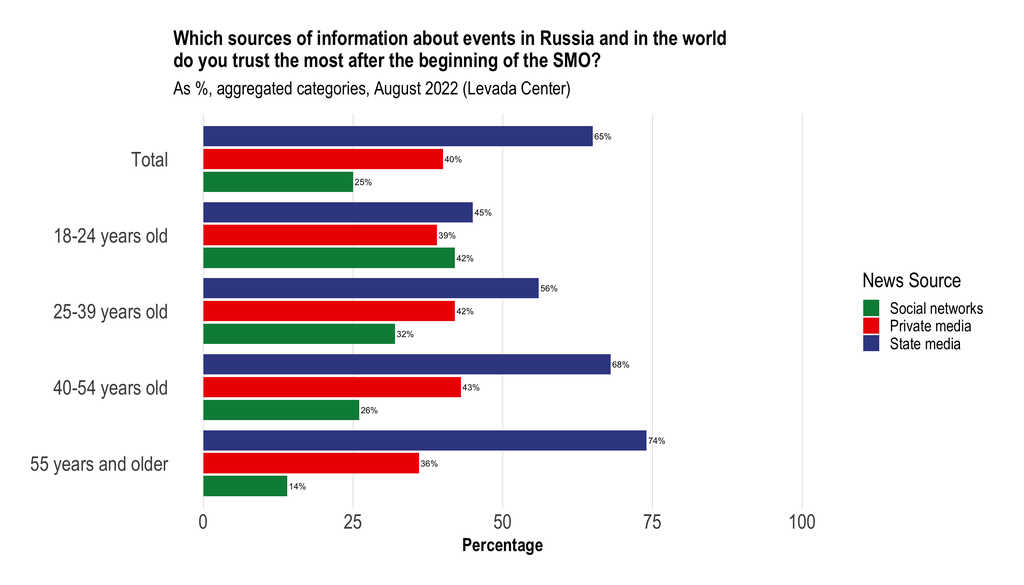

## Why Russians consume propaganda?

- Majority of Russians trust news from state media that project a positive image of the government with both TV and social media playing major roles
- This can be caused by two main factors:
  - Lack of alternatives due to suppression of independent journalism $\Rightarrow$ *Brainwashing*
  - (Subconscious) Preference for news that confirm citizens beliefs $\Rightarrow$ *Self-selection*
- **Question:** **How can we reduce the effects of propaganda?**

## Two possible answers

- **Exposing citizens to alternative media** can have minimal effects
  - Limited take-up when citizens choose to consume state media on their own
  - Lack of prior exposure limits the amount of learning from new media
- **Media literacy interventions** sometimes work, but often fail or backfire
  - Especially if citizens might not trust the third party judgement (e.g. foreign researchers, NGOs)

## Our approach

- **Argument**: Prompting citizens to learn about features of media coverage *on their own* avoids:
  - Relying on others’ judgment
  - Attributing evidence to researchers’ political agenda
- **Our approach**: Encourage citizens to pay attention to and compare media coverage across outlets
- See whether this leads:
  - They notice when media do the *Kremlin’s bidding*?
  - They switch to less biased media?
  - They change their support for the regime?

## How does it work?

- Paying attention to media coverage can make citizens:
  1. Learn about what different outlets cover
  2. Change perceptions media outlet’s bias
  3. Seek better sources of information
  4. Change their political attitudes
- **But…** it can also affect **how** citizens watch news!

## Setting: Russia during the War

- An autocratic regime with state control of media environment
- The full-scale invasion in Ukraine exacerbated state media control
- State media is heavily pro-government
- But some *more balanced* media is still available

**$\Rightarrow$ Media beliefs and consumption are likely hard to shift**

## Study

- 4-wave panel study among 1176 adult Russians enrolled in online panel in August-October 2023:
  - Median age is 44 y.o.; 49% are female; majority with college degree; 74% are permanently employed
- **Experiment**: Random assignment to one of experimental groups at the end of wave 1
- **Intervention**: Complete content-analysis tasks **at the end** of survey in waves 1-3

## Timeline

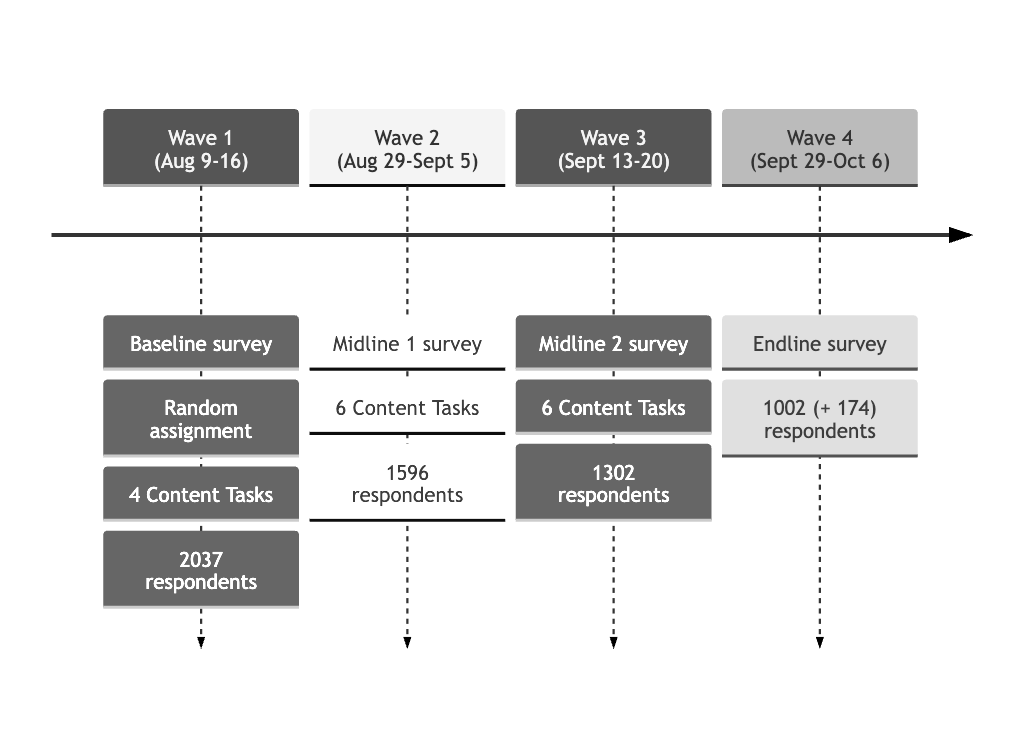

## Intervention

- 4–6 news headline segments per wave from combination of three TV stations:
  - **Rossiya-1** , the main state-controlled propaganda channel
  - **RTVI**, a private channel with moderately critical editorial policy
  - **Kultura**, a non-political channel that covers art, theater, architecture, etc.
- After each video, 6 questions asking to count how many times the following was discussed:
  - Situation in Russia in a **[negative/positive]** tone?
  - Russian federal officials in a **[negative/positive]** tone?
  - Situation in other countries in a **[negative/positive]** tone?

[figure not shown]

1. *Alexei Navalny was sentenced to 19 years in prison.*
2. *Unmanned aircraft attacked a naval base in Novorossiysk.*
3. *Lithuania annuls the visa for the residence of more than a thousand citizens of Russia and Belarus.*
4. *Landslide in Georgia.*
5. *The dollar is 96, the euro is 100. The currency exchange rate in Russia is breaking new records.*
6. *The Republicans will not vote for Trump if he is found guilty of the attack on the Capitol.*

[figure not shown]

1. *The equipment is not new and without spare parts. The first results of the Ukrainian counter-offensive. Losses in two months - more than 43,000 soldiers.*
2. *The Ministry of Defense have broken through the water blockade [in Donetsk] that Kiev has set up.*
3. *The IAEA mission is convinced that Russia has not mined the Zaporizhzhia Air Force. Ukraine is lying.*
4. *Biden can’t allow Trump become president, otherwise he will go to prison with his son.*
5. *The strongest landslide in Georgia.*

## Experimental conditions: Order & Composition

**Kultura**:

1. Kultura (Date 1)
2. Kultura (Date 2)
3. Kultura (Date 3)
4. Kultura (Date 4)
5. …

**Control group**

**Rossiya-1 & Kultura**:

1. Rossiya-1 (Date 1)
2. Kultura (Date 1)
3. Rossiya-1 (Date 2)
4. Kultura (Date 2)
5. …

**State group**

**Rossiya-1 & RTVI**:

1. Rossiya-1 (Date 1)
2. RTVI (Date 1)
3. Rossiya-1 (Date 2)
4. RTVI (Date 2)
5. …

**State + Independent group**

# Sample characteristics

## Where do Russian get their news from?

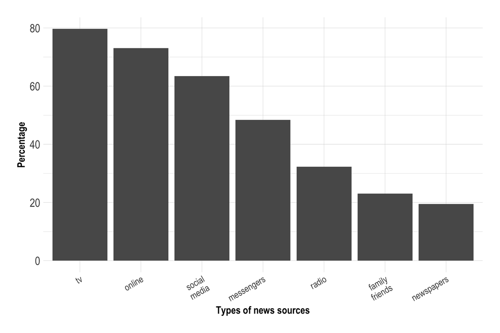

## Where do Russian get their news from?

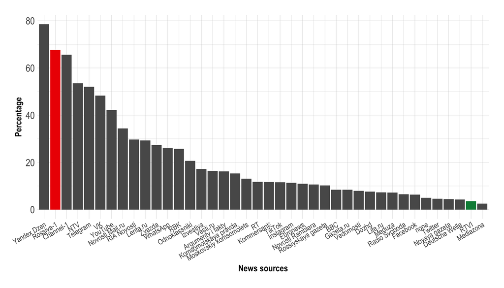

## Why do they choose state media?

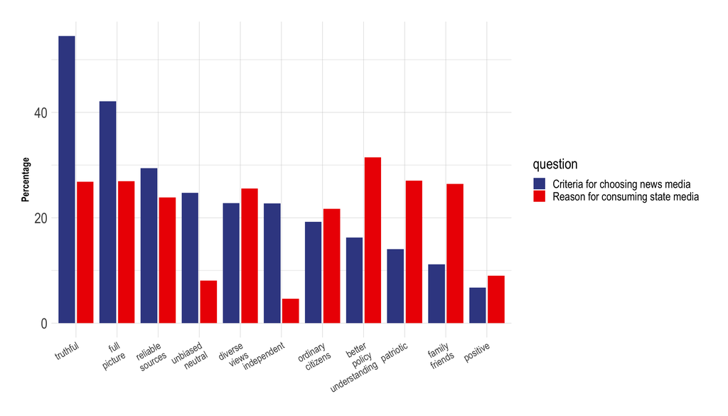

## How do they feel about government?

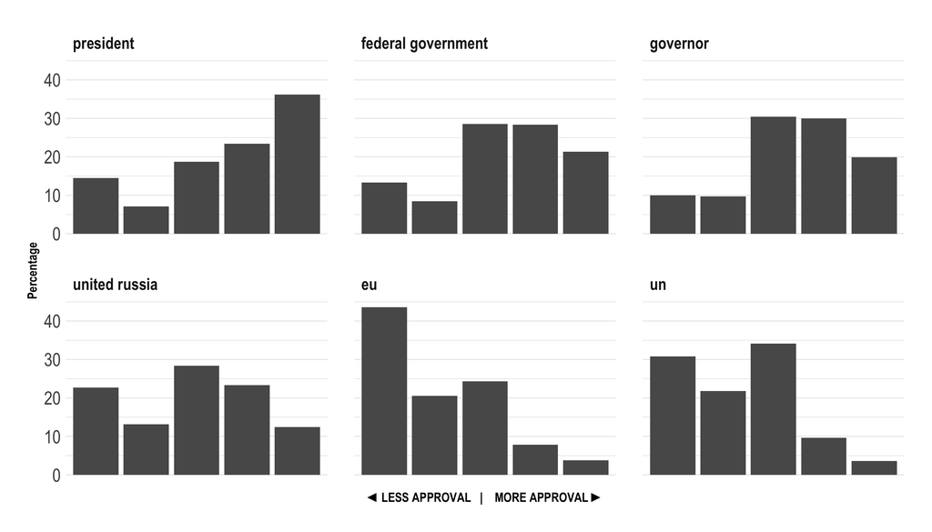

## Does the government spend enough effort on policies?

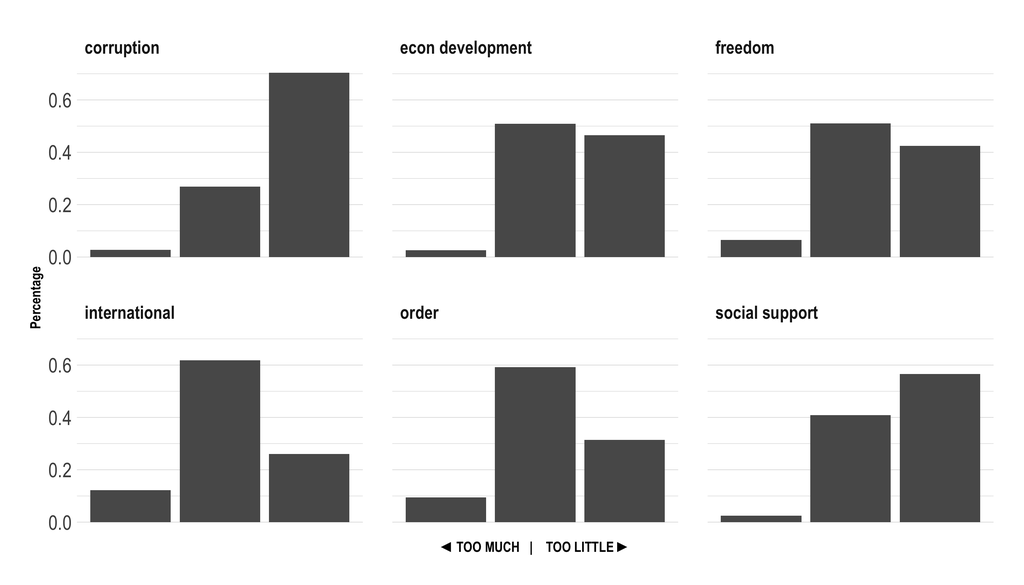

# Experimental results

[figure not shown]

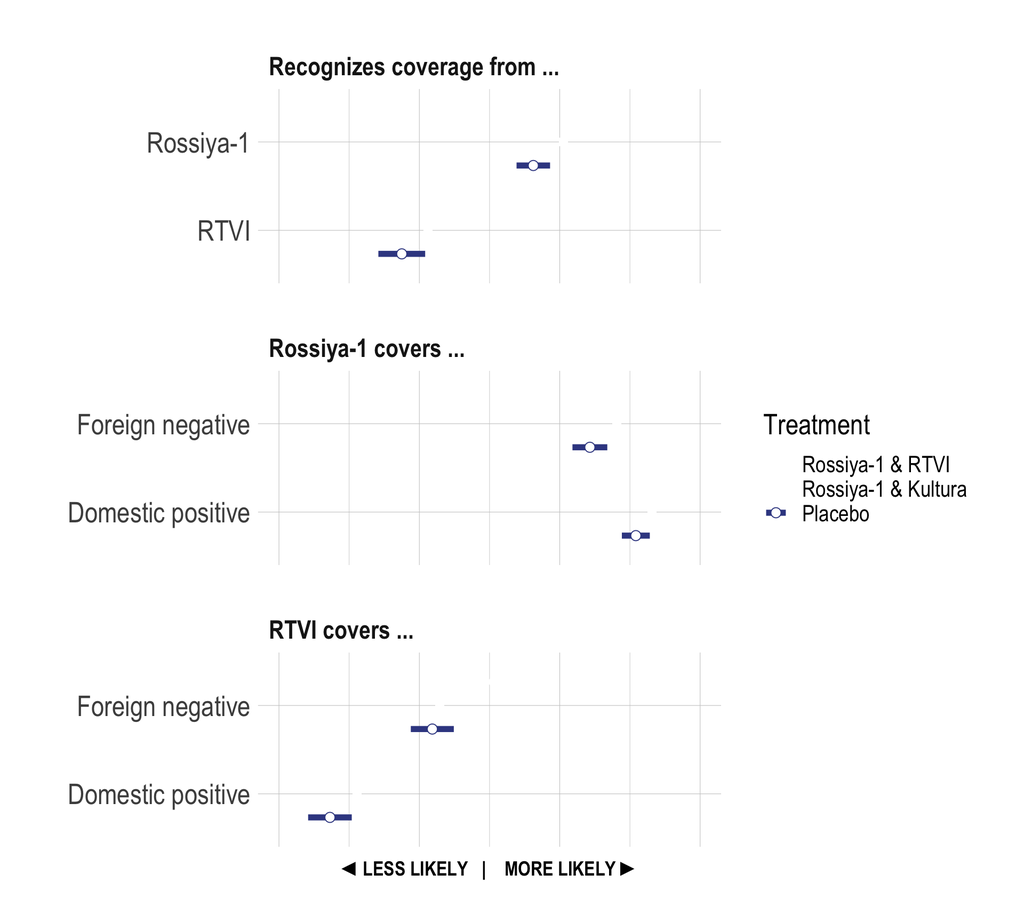

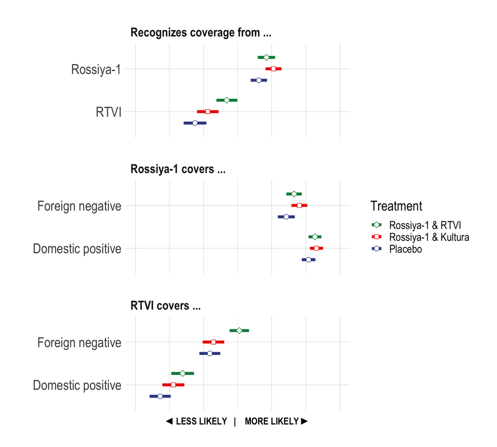

### Do Russians notice differences in news coverage?

- Control group: Less knowledge about independent media coverage
- Learning about what RTVI and Rossiya-1 cover
- Especially for independent media in respective group

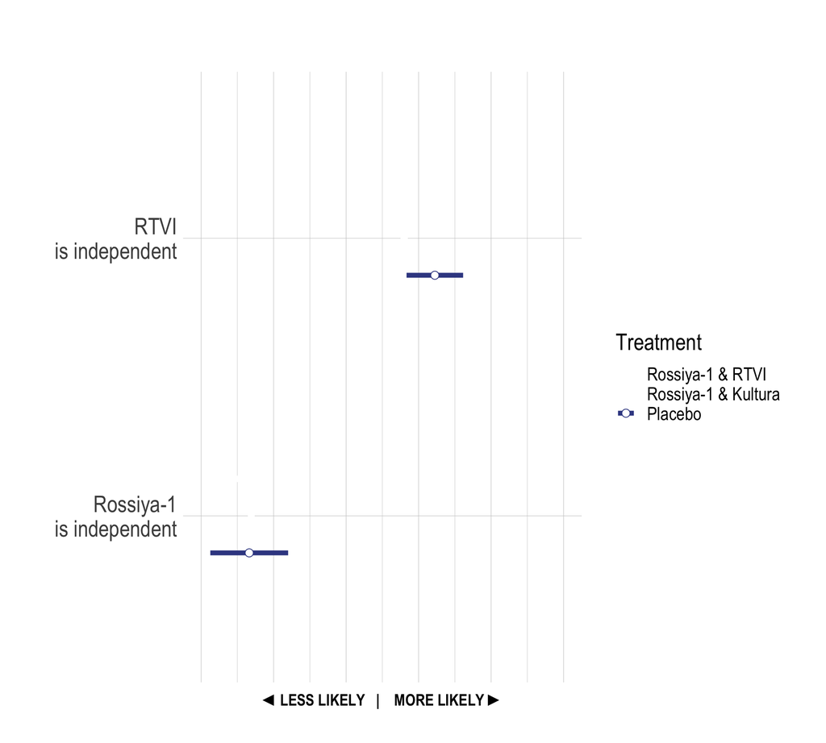

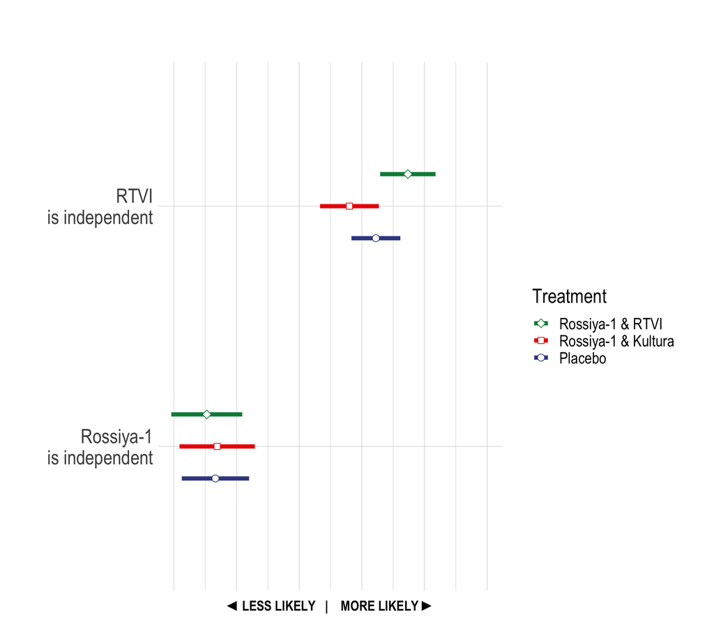

### Do they learn that the state media channel is biased?

- Control group: State media is more biased than independent
- No change in perceptions of state media
- But improved perceptions of independent media in respective group

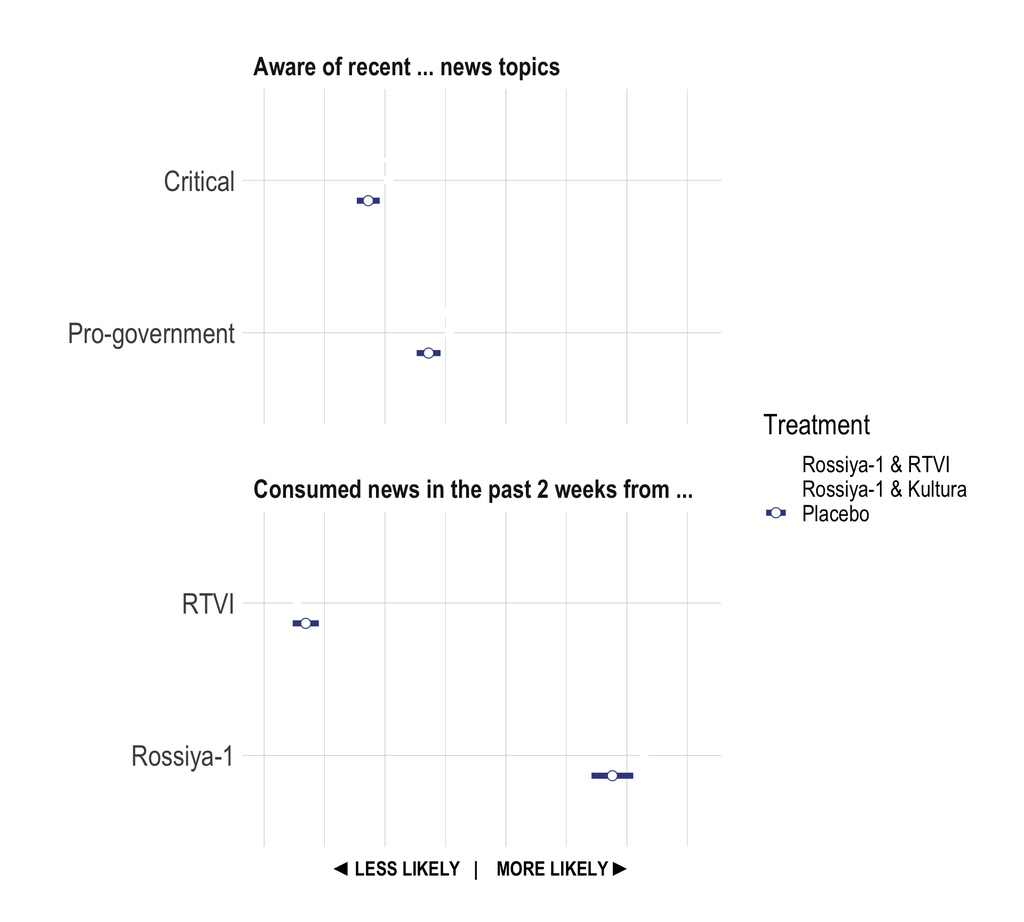

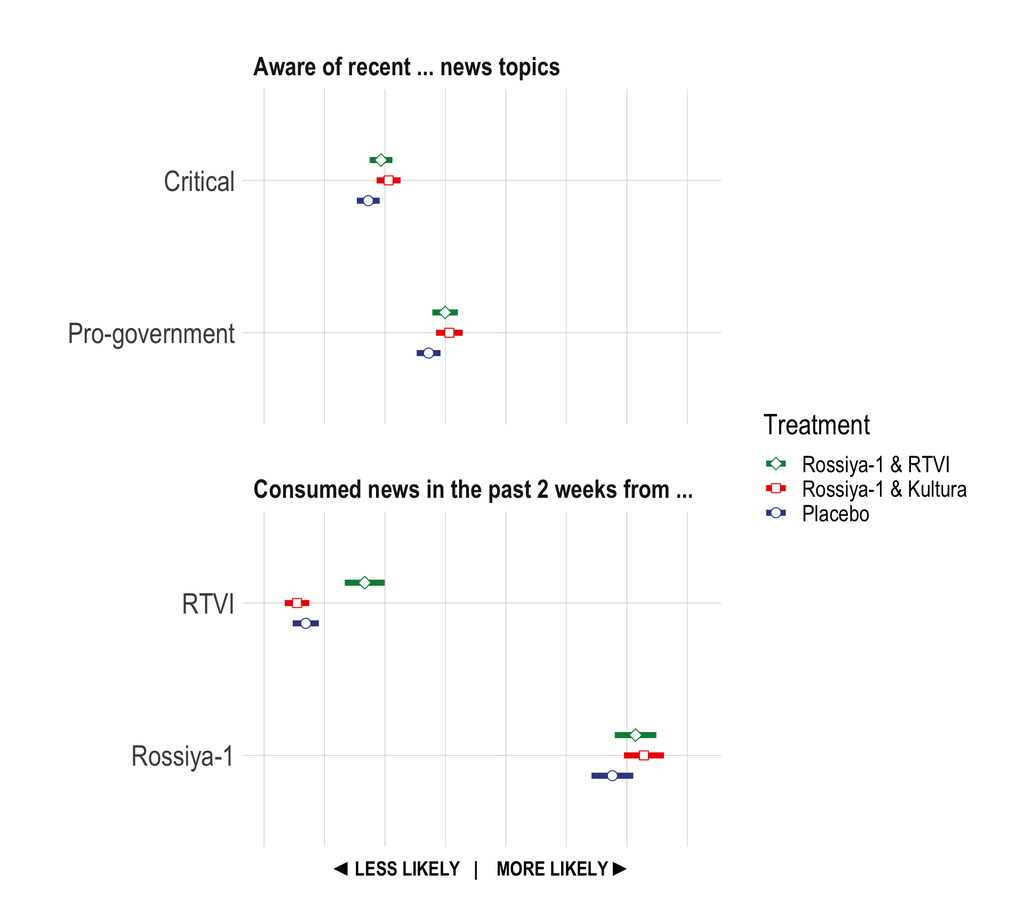

### Do they start to seek more independent news?

- Control group: Likely to consume state media
- Increased awareness of both pro-government and critical news
- Increased consumption of both Rossiya-1 and RTVI

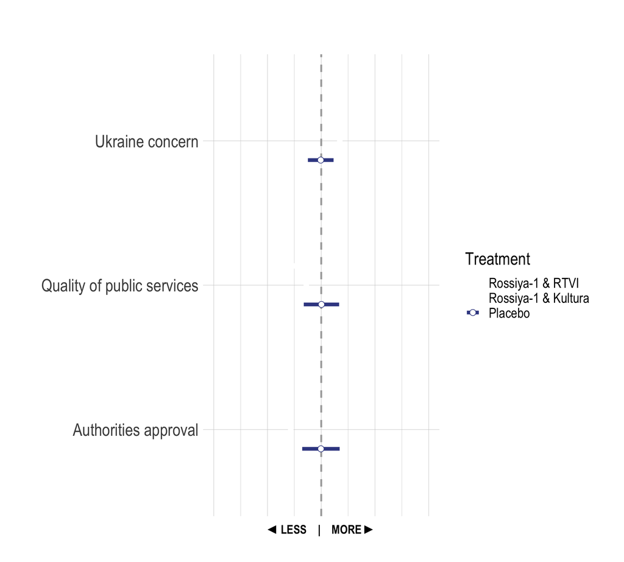

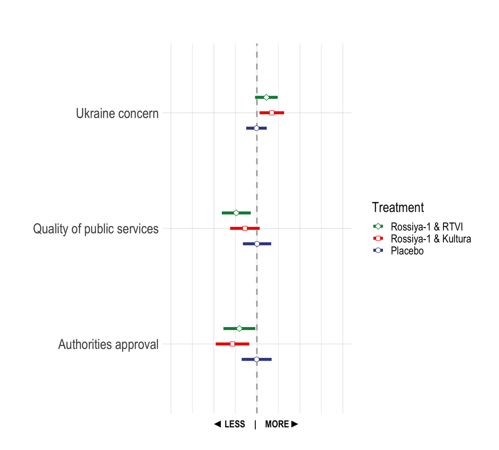

### Did their political beliefs change?

- Lower support for the government and stronger concerns about Ukraine
- This happens even after exposure to Rossiya-1 coverage only!

## Yet, effects depended on prior political dispositions

- Changes in perceptions of independent media and interest in it **only among Putin critics**, not supporters
- **News awareness** about pro-gov’t news $\Uparrow$ mainly **among supporters**; critical news $\Uparrow$ mainly **among critics**
- **Approval of authorities** $\Downarrow$, and concern about Ukraine $\Uparrow$ **among Putin critics**

## Takeaways

- Simply asking Russians to pay attention to what state or independent media covers **can** change political attitudes!
- This does not happen because of learning about bias or shifting away from the *popular propaganda* $\Rightarrow$ possibly caused by the change in **how** media is consumed
- The political effects are limited to those who are more critical of the government in the first place
  - Only those already skeptical (a minority) are affected by such interventions
  - Receptivity to critical information may increase only when regime support substantially weakens